# A general pipeline for looking at mutli-trait multiple-qtl models

JT Lovell

2016-11-01

```r
library(devtools)
install_github("jtlovell/qtlTools")
```

```
## Skipping install of 'qtlTools' from a github remote, the SHA1 (f73cf562) has not changed since last install.
##   Use `force = TRUE` to force installation
```

```r
library(qtlTools)
library(qtl)
library(ggplot2)
library(lsmeans)
library(qtlpvl)
```

For this tutorial, we will use the dataset `multitrait` from R/qtl.

```r
data(multitrait)
cross<-multitrait
cross<-calc.genoprob(cross)
phes<-phenames(cross)
```

In R/qtl there is a pipeline to analyze [multiple traits in a single model](http://www.rqtl.org/tutorials/MQM-tour.pdf). Here, we will discuss analyzing them independently, then concatenating the results

### Scanones

In the simplest case, we can run a bunch of scanones

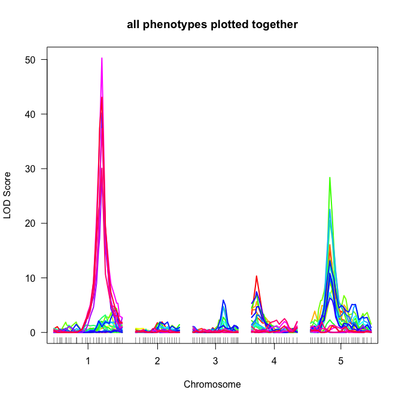

```r
s1<-scanone(cross, pheno.col = phes, method = "hk")
cols<-rainbow(length(phes))
plot(s1, type="n", ylim = c(0,max(as.matrix(s1[,-c(1:2)]))),
     ylab = "LOD Score", main = "all phenotypes plotted together")
for(i in 1:length(phes)) plot(s1, add=T, lodcolumn = i, col = cols[i])
```

### QTL peaks from scanones

This simplest way to look at these data is to pull out only the significant QTL peaks

```r
perms<-scanone(cross, pheno.col = phes, method = "hk", n.perm = 100, verbose=F)
print(pullSigQTL(cross, pheno.col=phes,
                 s1.output = s1,  perm.output = perms,
                 returnQTLModel=FALSE, alpha = 0.05,
                 controlAcrossCol = TRUE))
```

```
##                                    pheno chr      lod1     pos
## 7                X7.Methylsulfinylheptyl   1  4.592547 112.183
## 11                           X2.Propenyl   1  3.200351  95.126
## 16                   X7.Methylthioheptyl   1  4.078659 112.183
## 19     Quercetin.deoxyhexosyl.dihexoside   1 40.230510  88.617
## 20  Kaempferol.dideoxyhexosyl.dihexoside   1 28.398452  88.617
## 21       Quercetin.deoxyhexosyl.hexoside   1 50.260233  88.617
## 22   Isohamnetin.deoxyhesoxyl.dihexoside   1 37.347156  88.617
## 23     Isohamnetin.deoxyhesoxyl.hexoside   1 30.070622  88.617
## 24    Kaempferol.dideoxyhexosyl.hexoside   1 43.080414  88.617
## 55               X7.Methylsulfinylheptyl   3  4.709009  55.937
## 62                X6.Methylsulfinylhexyl   3  4.744972  55.937
## 64                   X7.Methylthioheptyl   3  5.923296  55.937
## 73                      X3.Hydroxypropyl   4 10.339584   9.027
## 75                X4.Methylsulfinylbutyl   4  4.210679   7.328
```

[output cut: 23 more lines]

However, if we want to look at model statistics etc. it is best to create multiple qtl models for each phenotype

```r
mods<-pullSigQTL(cross, pheno.col=phes,
                 s1.output = s1,  perm.output = perms,
                 returnQTLModel=TRUE, alpha = 0.05,
                 controlAcrossCol = TRUE)
```

This returns a list of fitted QTL models, which we could use to calculate confidence intervals etc.

```r
print(mods[1:5])
```

```
## $X3.Hydroxypropyl
##   QTL object containing genotype probabilities.
##
##      name chr    pos n.gen
## Q1  4@9.0   4  9.027     2
## Q2 5@35.4   5 35.356     2
##
## $X4.Hydroxybutyl
##   QTL object containing genotype probabilities.
##
##      name chr    pos n.gen
## Q1 5@35.4   5 35.356     2
##
## $X4.Methylsulfinylbutyl
##   QTL object containing genotype probabilities.
##
##      name chr    pos n.gen
## Q1  4@7.3   4  7.328     2
## Q2 5@35.4   5 35.356     2
##
## $X3.Butenyl
##   QTL object containing genotype probabilities.
##
##      name chr    pos n.gen
## Q1  4@9.0   4  9.027     2
## Q2 5@35.4   5 35.356     2
##
## $X3.Methylthiopropyl
## [1] "NULL QTL Model"
```

We can also plot confidence intervals directly from scanone data, however, it is important to note that multiple peaks on a single chromosome can violate assumptions of such intervals.

```r
cis<-calcCis(cross,s1.output=s1, perm.output=perms)
head(cis)
```

```
##                                  pheno qtlname chr     pos    maxLod
## 1              X3.Methylsulfinylpropyl      NA   1 105.304  3.624535
## 2              X7.Methylsulfinylheptyl      NA   1 112.183  4.592547
## 3                          X2.Propenyl      NA   1  95.126  3.200351
## 4                  X7.Methylthioheptyl      NA   1 112.183  4.078659
## 5    Quercetin.deoxyhexosyl.dihexoside      NA   1  88.617 40.230510
## 6 Kaempferol.dideoxyhexosyl.dihexoside      NA   1  88.617 28.398452
##     lowmarker  highmarker lowposition highposition
## 1     CH.215L     CC.318C      95.126      112.183
## 2     BF.116C  FD.90L-Col     102.114      118.105
## 3 DF.260L-Col HH.360L-Col      82.554      126.083
## 4     BF.116C  FD.90L-Col     102.114      118.105
## 5      EC.88C     CH.215L      84.414       95.126
## 6      EC.88C     CH.215L      84.414       95.126
```

We might be interested in where these QTL are - we can plot these on the genetic map

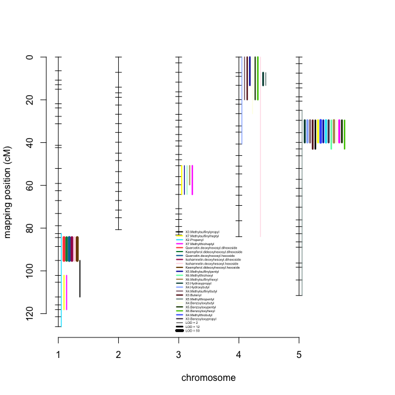

```r
segmentsOnMap(cross, calcCisResults = cis, legendCex = .35)
```

### Multiple QTL models

The approach above is nice because it is super fast, but it does not necessarily produce the best models (e.g. there can only be one QTL/chromosome). One could use stepwiseqtl to generate the models instead, however, scantwo permutations are needed for this appraoch, which is slow for many traits.

For the purposes of this tutorial, we will use the models generated through scanones to make statistical inference. The function `qtlStats` takes a qtl model and returns fitted statistics. For a single phenotype, we’d run it as follows:

```r
mod<-mods[["X3.Methylsulfinylpropyl"]]
form<-paste("y ~",paste(mod$altname, collapse = " + "))
mod<-refineqtl(cross, qtl = mod, formula = form, verbose=F, method="hk")
qtlStats(cross,
         pheno.col = "X3.Methylsulfinylpropyl",
         form = form,
         mod = mod)
```

```
##    terms altnames qtlnames               phenotype formula df Type.III.SS
## 1 5@35.4       Q1   5@35.4 X3.Methylsulfinylpropyl  y ~ Q1  1     3149184
##        LOD    X.var F.value Pvalue.Chi2.    Pvalue.F. modelLod
## 1 6.682608 17.69807      NA 2.898142e-08 3.721645e-08 6.682608
##   modelPercVar       est       SE         t pheno chr    pos   maxLod
## 1     17.69807 -143.1918 24.72281 -5.791889    NA   5 35.356 12.97081
##     lowmarker  highmarker lowposition highposition
## 1 DF.184L-Col GH.121L-Col      29.579       39.922
```

Since mods is a list, we can loop through it using lapply First toss out an NULL QTL models

```r
mods<-mods[sapply(mods,length)!=1] # a NULL QTL model has length = 1, toss these
```

Next do the loop, where `x` represents each phenotype.

```r
stats<-lapply(names(mods), function(x){
  mod<-mods[[x]]
  form<-paste("y ~",paste(mod$altname, collapse = " + "))
  mod<-refineqtl(cross, qtl = mod, formula = form,
                verbose=F, method="hk", pheno.col = x)
  qtlStats(cross,
         pheno.col = x,
         form = form,
         mod = mod)
})
stats<-do.call(rbind, stats)
print(head(stats))
```

```
##    terms altnames qtlnames              phenotype     formula df
## 1  4@7.3       Q1    4@7.3       X3.Hydroxypropyl y ~ Q1 + Q2  1
## 2 5@35.4       Q2   5@35.4       X3.Hydroxypropyl y ~ Q1 + Q2  1
## 3 5@35.4       Q1   5@35.4        X4.Hydroxybutyl      y ~ Q1  1
## 4  4@9.0       Q1    4@9.0 X4.Methylsulfinylbutyl y ~ Q1 + Q2  1
## 5 5@35.4       Q2   5@35.4 X4.Methylsulfinylbutyl y ~ Q1 + Q2  1
## 6  4@0.0       Q1    4@0.0             X3.Butenyl y ~ Q1 + Q2  1
##    Type.III.SS       LOD    X.var   F.value Pvalue.Chi2.    Pvalue.F.
## 1 1122065752.9 14.816762 24.02963  83.71827 1.110223e-16 3.330669e-16
## 2 1546146184.2 19.087155 33.11154 115.35926 0.000000e+00 0.000000e+00
## 3     571087.8 15.389754 36.14528        NA 0.000000e+00 0.000000e+00
## 4  310708817.6  7.277717 11.96404  36.62612 7.071197e-09 1.034805e-08
## 5 1017169703.3 19.658997 39.16675 119.90318 0.000000e+00 0.000000e+00
## 6  961915216.0  7.206661 14.57554  36.22966 8.366950e-09 1.220014e-08
##   modelLod modelPercVar         est         SE          t pheno chr    pos
## 1 27.78757     55.51039 -2688.59616 293.843073  -9.149769    NA   4  7.328
## 2 27.78757     55.51039 -3174.21911 295.536186 -10.740543    NA   5 35.356
## 3 15.38975     36.14528    60.97761   6.489016   9.397052    NA   5 35.356
## 4 23.35094     49.36876 -1411.58194 233.244097  -6.051951    NA   4  9.027
## 5 23.35094     49.36876  2575.80850 235.232986  10.950031    NA   5 35.356
## 6 16.20352     37.64200  2484.69093 412.800516   6.019108    NA   4  0.000
##      maxLod   lowmarker  highmarker lowposition highposition
## 1 14.816762        ANL2        C6L9       0.000       13.229
## 2 19.087155 DF.184L-Col GH.121L-Col      29.579       39.922
## 3 15.389754 DF.184L-Col GH.121L-Col      29.579       39.922
## 4  7.277717        ANL2        C6L9       0.000       13.229
## 5 19.658997 DF.184L-Col GH.121L-Col      29.579       39.922
## 6  7.206661        ANL2        C6L9       0.000       13.229
```

### Plotting multiple QTL models

The most basic way to present these data is to show the position of QTL intervals on a genetic map. `qtlTools::segmentsOnMap` provides one method to do this.

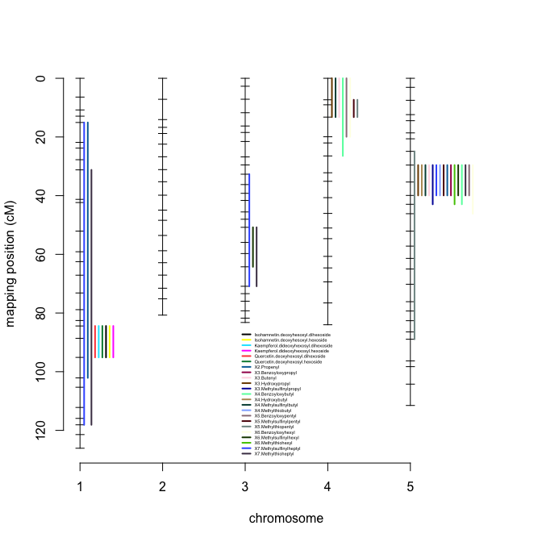

```r
segmentsOnMap(cross=cross, phe=stats$phenotype,
              chr=stats$chr,
              l = stats$lowposition, lwd=2,
              h =stats$highposition,legendCex=.35, leg.inset=.01)
```